# Network-Exam

Kwaku

March 13, 2024

Question 1:

1.1 Networks can be found from different sources from the internet, communication networks, social networksl ike twitter and facebook. Network analysis can be applied in different fields of study from Medicine, Biology, Social Sciences, Marketing, Fraud Detectection (Finance), and for Security and Defense. Networks can be characterised as graphs. An example is a social network like twitter where interactions between users and their followers can be constructed and depicted as a graph network. Another characterisation of a network is an adjacency matrix where entries of the columns an rows depict a connection or otherwise between them. The columns and row represent nodes where as their entries correspond to an existence of a connection or otherwise between the nodes. Another type of network can be found in transactional data such as emails of a company. Such a data can be depicted in a way that shows trends and common patterns and provide graphical representation of a network. Another type of network can be constructed from sources of different sources like form one or several documents or from different locations. Also from different types like from text, phone calls, text messages and tweets.

1.2 The Stochastic Block Model (SBM) is for providing the clusters of the network. Its aim is to recover the clusters or communities and the stars at the same time.The stars are the people in a community that connect less within the group than outside the group. The output of the SBM can also be seen as the summary or meta-network of the network. It provides the communities within the network as well as their probability to connect within and outside their communities. The re-organised adjacency matrix from SBM blocks represents the communities and indicates which groups are stars. It thus provides an easy way to recover and detect communities and stars. By just observing this output of the model, one can easily identify who are the stars and also the communities at a glance.

Question 2

```r
library(dplyr)
```

```r
library(igraph)
library(sna)
library(ggraph)
library(greed)
library(tidygraph)
emails <- read.csv("C:/Users/DELL/OneDrive/Desktop/ClintonEmails/ClintonEmails/Emails.csv")
email_receivers <- read.csv("C:/Users/DELL/OneDrive/Desktop/ClintonEmails/ClintonEmails/EmailReceivers.csv")
persons <- read.csv("C:/Users/DELL/OneDrive/Desktop/ClintonEmails/ClintonEmails/Persons.csv")
aliases <- read.csv("C:/Users/DELL/OneDrive/Desktop/ClintonEmails/ClintonEmails/Aliases.csv")
```

```r
# Merge datasets
data <- merge(emails, email_receivers, by = "Id")
data <- merge(data, persons, by = "Id")
data <- merge(data, aliases, by = "PersonId")
```

We plot our network by creating a network object and visualizing using the sna package

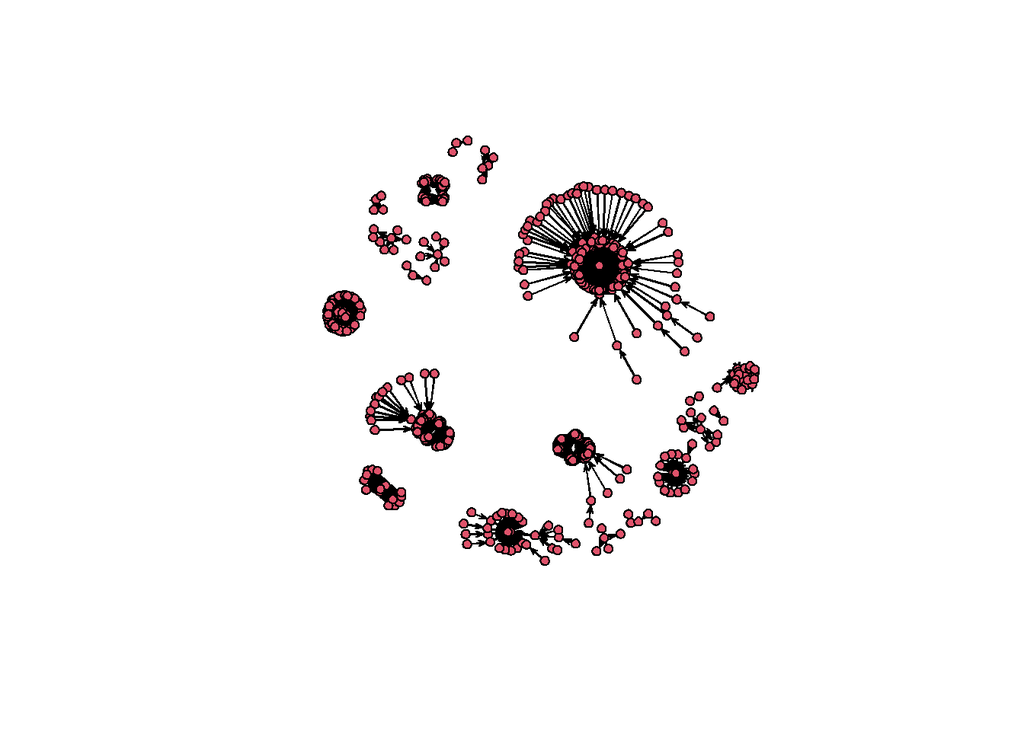

```r
# Create an edge list dataframe using sender and receiver information
edg_lst <- data.frame(from = data$Name, to = data$Alias)

# Remove loops from the edge list dataframe
edg_lst <- edg_lst[edg_lst$from != edg_lst$to, ]

# Filter out missing
edg_list <- na.omit(edg_lst)

# Remove duplicate rows
edg_lst <- unique(edg_lst)

network <- network(edg_lst, directed = TRUE, loops = FALSE)

plot(network)
```

```r
#Convert network graph into an adjacency matrix
A <- as.matrix(network)
```

#The Latent Space Model

We define a loss function and create an LSM function

```r
LSM.loss <- function(par,A){
  alpha = par[1]
  Z = matrix(par[-1],ncol=2)
  D.out = as.matrix(dist(Z))
  log.lik =  sum(A * (alpha - D.out) - log(1+exp(alpha - D.out)))
  return(-log.lik)
}

lsm_func <- function(A){
  n = nrow(A)
  alpha.init = 0
  z.init = runif(2*n,-1,1)
  par.init = c(alpha.init,z.init)
  out = optim(par.init,LSM.loss,A=A,method="SANN")
  list(alpha = out$par[1],
      Z.final = matrix(out$par[-1],ncol = 2),
      loss = out$value,
      Z.init = matrix(z.init,ncol=2))
}
```

We fit our LSM function to retrieve our latent space solution for our network using our adjacency matrix that contains information about our nodes and their connections in the latent space

```r
res = lsm_func(A)
```

We plot our latent space solution

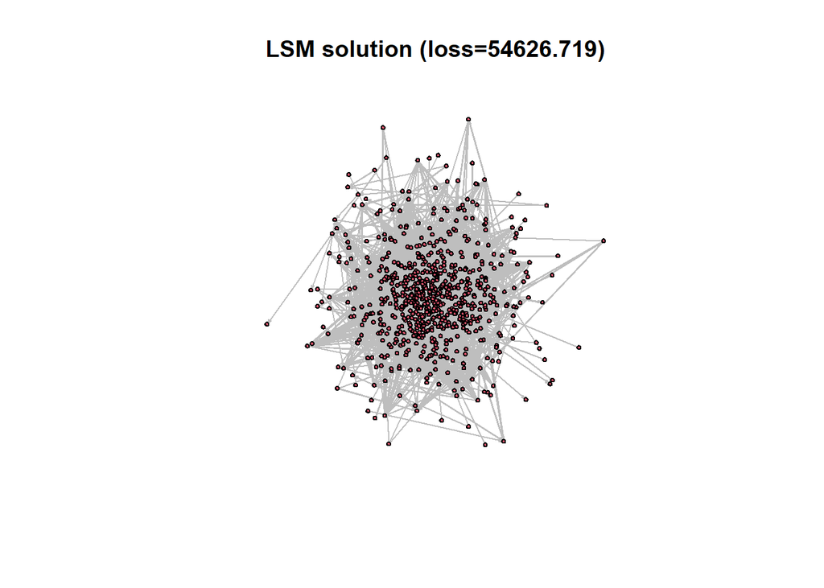

```r
gplot(A,coord=res$Z.final,edge.col="gray")
title(main=paste("LSM solution (loss=",round(res$loss,3),")",sep=''))
```

## SBM

We use the SBM algorithm in the greed package to recover both the clusters and the model parameters.

```r
sbm_out <- greed(A,model = Sbm())
```

```
## ── Fitting a guess SBM model ──
```

```
## ℹ Initializing a population of 20 solutions.
```

```
## ℹ Generation 1 : best solution with an ICL of -11204 and 10 clusters.
```

```
## ℹ Generation 2 : best solution with an ICL of -4505 and 11 clusters.
```

```
## ℹ Generation 3 : best solution with an ICL of -4448 and 13 clusters.
```

```
## ℹ Generation 4 : best solution with an ICL of -4448 and 13 clusters.
```

```
## ── Final clustering ──
```

```
## ── Clustering with a SBM model 13 clusters and an ICL of -4448
```

We can get the estimated parameters through the coef() function for the model. pi provide the probability a node to belong to a cluster theta represents the probality of interaction between the blocks or clusters

```r
params = coef(sbm_out)
params$pi
```

```
##  [1] 0.04323570 0.05299861 0.07810321 0.05578801 0.06973501 0.02928870
##  [7] 0.06694561 0.04323570 0.06276151 0.18549512 0.01673640 0.01534170
## [13] 0.28033473
```

```r
round(params$theta,3)
```

```
##       [,1] [,2]  [,3] [,4]  [,5] [,6] [,7]  [,8]  [,9] [,10] [,11] [,12] [,13]
##  [1,]    0    0 0.000    0 0.000    0    0 0.000 0.000 0.000     0     0 0.000
##  [2,]    0    0 0.000    0 0.000    0    0 0.000 0.000 0.000     0     0 0.000
##  [3,]    0    1 0.000    0 0.000    0    0 0.000 0.000 0.000     0     0 0.000
##  [4,]    0    0 0.000    0 0.000    0    0 0.000 0.000 0.000     0     0 0.000
##  [5,]    0    0 0.000    1 0.000    0    0 0.000 0.000 0.000     0     0 0.000
##  [6,]    0    0 0.000    0 0.000    0    0 0.000 0.000 0.000     0     0 0.000
##  [7,]    0    0 0.000    0 0.000    1    0 0.000 0.000 0.000     0     0 0.000
##  [8,]    0    0 0.000    0 0.000    0    0 0.000 0.000 0.000     0     0 0.000
##  [9,]    0    0 0.000    0 0.000    0    0 0.199 0.000 0.000     0     0 0.000
## [10,]    0    0 0.002    0 0.001    0    0 0.000 0.002 0.003     0     0 0.002
## [11,]    0    0 0.000    0 0.000    0    0 0.000 0.000 0.000     0     1 0.000
## [12,]    0    0 0.000    0 0.000    0    0 0.000 0.000 0.000     0     0 0.000
## [13,]    1    0 0.000    0 0.000    0    0 0.000 0.000 0.000     0     0 0.000
```

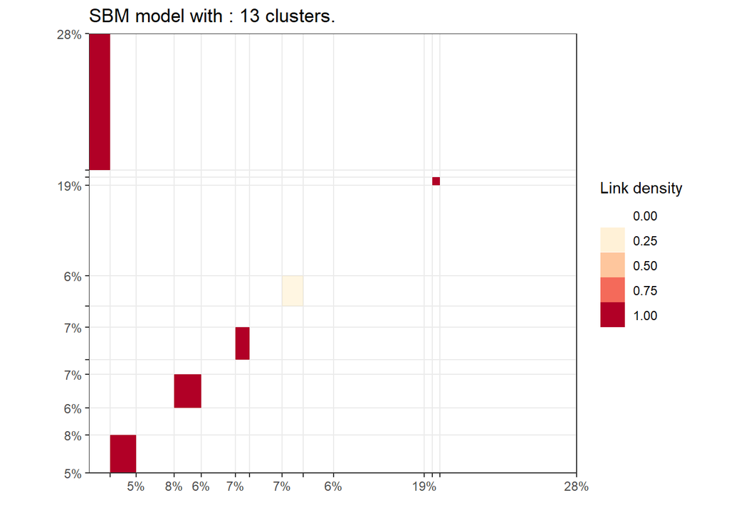

```r
plot(sbm_out,type='blocks')
```

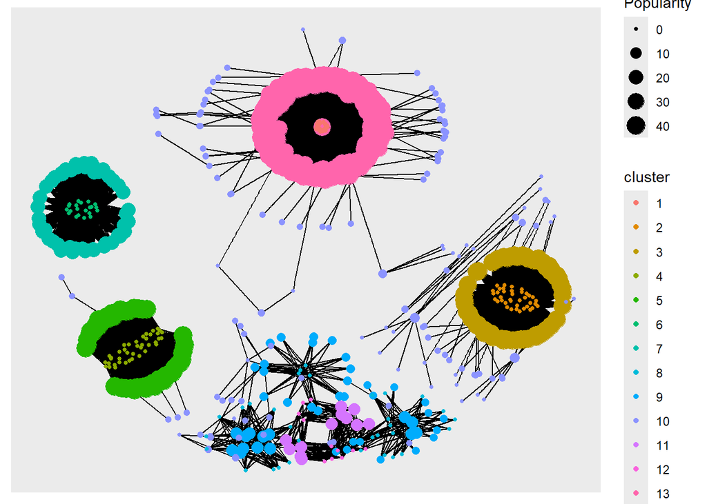

```r
graph <- igraph::graph_from_adjacency_matrix(A) %>% as_tbl_graph() %>%
    mutate(Popularity = centrality_degree())  %>%
    activate(nodes) %>%
    mutate(cluster=factor(clustering(sbm_out),1:K(sbm_out)))

# plot using ggraph
ggraph(graph, layout = 'kk') +
    geom_edge_link() +
    geom_node_point(aes(size = Popularity,color=cluster))
```

We can analyse the data for email exchanges that have the word ‘LIBYA’ or ‘Libya’ in it

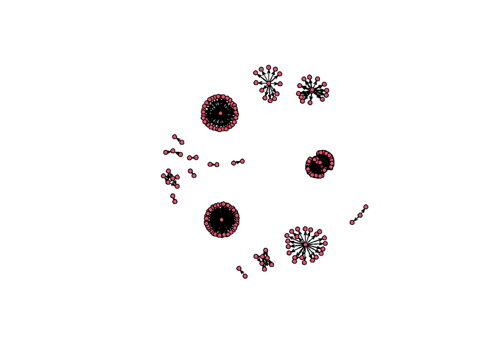

```r
flt_data <- data[grep("LIBYA|Libya", data$MetadataSubject), ]

edg_lst <- data.frame(from = flt_data$Name, to = flt_data$Alias)

edg_lst <- unique(edg_lst)

network <- network(edg_lst, directed = TRUE, loops = FALSE)

plot(network)
```

## LSM

Define a loss function and an LSM function

```r
LSM.loss <- function(par,A){
  alpha = par[1]
  Z = matrix(par[-1],ncol=2)
  D.out = as.matrix(dist(Z))
  log.lik =  sum(A * (alpha - D.out) - log(1+exp(alpha - D.out)))
  return(-log.lik)
}

lsm_func2 <- function(A){
  n = nrow(A)
  alpha.init = 0
  z.init = runif(2*n,-1,1)
  par.init = c(alpha.init,z.init)
  out = optim(par.init,LSM.loss,A=A,method="SANN")
  list(alpha = out$par[1],
      Z.final = matrix(out$par[-1],ncol = 2),
      loss = out$value,
      Z.init = matrix(z.init,ncol=2))
}
```

```r
A <- as.matrix(network)
```

We run and plot the latent space solution

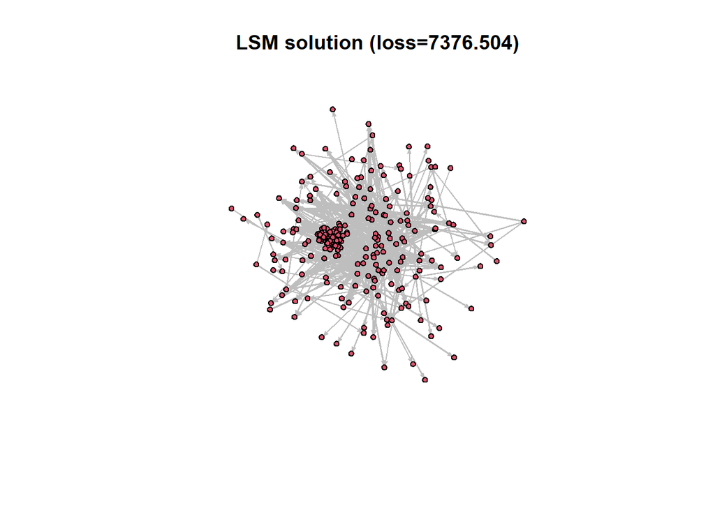

```r
res = lsm_func2(A)

gplot(A,coord=res$Z.final,edge.col="gray")
title(main=paste("LSM solution (loss=",round(res$loss,3),")",sep=''))
```